# Anális de datos RUES

En este notebook realizamos una limpieza y análisis de los datos obtenidos mediante [web-scraping](https://github.com/pabloibargon/scraper).

```python
# Imports
import pandas as pd
import numpy as np
from IPython.display import display, HTML
import warnings
warnings.filterwarnings('ignore')
```

## Carga del dataset original

```python
df = pd.read_csv('dataset/rues_20251109_042421.csv')
```

## Análisis de la calidad de los datos

```python
# Resumen de columnas numéricas
display(df.describe().T)
# Resumen de columnas no numéricas
df.describe(exclude="number").T
```

|  | count | mean | std | min | 25% | 50% | 75% | max |
| --- | --- | --- | --- | --- | --- | --- | --- | --- |
| Número de Matrícula | 4377.0 | 6.897020e+08 | 2.359404e+09 | 2.0 | 141816.0 | 17618504.0 | 38794512.0 | 9.000701e+09 |
| Último año renovado | 4377.0 | 1.708965e+03 | 7.196395e+02 | 0.0 | 1997.0 | 2010.0 | 2021.0 | 2.025000e+03 |

|  | count | unique | top | freq |
| --- | --- | --- | --- | --- |
| Identificación | 4377 | 3695 | SIN IDENTIFICACION | 335 |
| Estado de la matrícula | 4377 | 3 | Activa | 4371 |
| nombre | 4377 | 4377 | COMERCIALIZADORA LA LLAMA S A | 1 |
| Categoria de la Matrícula | 4377 | 3 | Sociedad ó persona juridica principal ó esal | 4362 |
| Tipo de Sociedad | 4377 | 5 | Sociedad comercial | 3918 |
| Tipo Organización | 4376 | 23 | Sociedades por acciones simplificadas sas | 1854 |
| Cámara de Comercio | 4377 | 55 | Medellin para antioquia | 2005 |
| Fecha de Matrícula | 4362 | 2862 | 1996/05/01 | 29 |
| Fecha de Vigencia | 4361 | 1946 | Indefinido | 2065 |
| Fecha de Cancelación | 1 | 1 | 2024/12/14 | 1 |
| Fecha de renovación | 3131 | 1964 | 2025/03/31 | 94 |
| Fecha de Actualización | 4011 | 736 | 2020/11/21 | 318 |
| Motivo Cancelación | 1904 | 1 | NORMAL | 1904 |
| Emprendimiento Social | 632 | 2 | N | 568 |
| Extinción de Dominio | 101 | 1 | N | 101 |

### Resultados:

En vista a los resumenes observamos que la mayoría de columnas del dataframe según lo hemos cargado son no númericas, de hecho las dos variables númericas encontradas son el número de matrícula y el año que no son realmente numéricas.

La mayoría de columnas tienen pocos valores directamente faltantes pero se observan valores que marcan columnas vacías o desconocidas:

- El mínimo del año es 0, marcaremos este dato como nulo
- En identificación el dato más frecuente es la cadena: "SIN IDENTIFICACION"
- En la Fecha de vigencia el dato máß frecuente es la cadena "Indefinido", esto es posible que se de en otros campos de tipo fecha. Sin embargo en estos caso una acción especial no será necesaria: cuando convirtamos el valor a tipo fecha fallará la conversión y tendremos un valor nulo.
- La columna de fecha de cancelación solo tiene un registro no nulo, con lo que esta columna deberá ser completamente descartada.

Otra cosa que podemos observar es varias variables con un número de valores únicos bajo, estas columnas son las propiamente categóricas:

- Estado de la matrícula
- Tipo de sociedad
- Tipo Organización
- Camara de Comercio
- Categoría de matricula
- Motivo de cancelación.

Un par de variables son booleanas marcadas con 'N' o 'S' (O nulos)

- Emprendimiento Social
- Extinción de Dominio

(Estas variables tiene alto número de nulos)

## Limpieza de los datos originales

### Variables categóricas

```python
# Convertir las variables categóricas al tipo adecuado
category_cols = ["Estado de la matrícula", "Tipo de Sociedad", "Tipo Organización", "Cámara de Comercio", "Categoria de la Matrícula"]
df[category_cols] = df[category_cols].astype("category")
```

```python
for col in df.select_dtypes(include="category"):
    cats = df[col].cat.categories

    table = (
        pd.DataFrame({"Categoría": cats})
        .to_html(index=False, escape=False)
    )

    display(HTML(f"<h3>{col}</h3>{table}"))
```

Estado de la matrícula

| Categoría |
| --- |
| Activa |
| Activa, constitución por traslado |
| Cancelada |

Categoria de la Matrícula

| Categoría |
| --- |
| Establecimiento de comercio |
| Persona natural |
| Sociedad ó persona juridica principal ó esal |

Tipo de Sociedad

| Categoría |
| --- |
| Economia solidaria |
| Entidad sin animo de lucro |
| No aplica |
| Sociedad civil |
| Sociedad comercial |

Tipo Organización

| Categoría |
| --- |
| Asociaciones agropecuarias y campesinas nacionales y no nacionales |
| Asociaciones de padres de familia |
| Asociaciones, corporaciones, fundaciones e instituciones de utilidad común (gremiales, de beneficencia; profesionales, juveniles, sociales, democráticas y participativas, cívicas y comunitarias, de eg… |
| Cooperativas, federaciones y confederaciones, instituciones auxiliares de la economía solidaria y precooperativas. |
| Corporaciones |
| Corporaciones, asociaciones y fundaciones creadas para adelantar actividades en comunidades indígenas. |
| Empresas asociativas de trabajo |
| Empresas unipersonales |
| Entidades científicas, tecnológicas, culturales, e investigativas |
| Entidades de naturaleza cooperativa |
| Establecimientos de comercio |
| Fondo de empleados |
| Fundaciones |
| Las demás organizaciones civiles,corporaciones,fundaciones |
| Otras sociedades |
| Persona natural |
| Sociedad anonima |
| Sociedad colectiva |
| Sociedad en comandita por acciones |
| Sociedad en comandita simple |
| Sociedad extranjera |
| Sociedad limitada |
| Sociedades por acciones simplificadas sas |

Cámara de Comercio

| Categoría |
| --- |
| Aburra sur |
| Aguachica |
| Amazonas |
| Arauca |
| Armenia |
| Barrancabermeja |
| Barranquilla |
| Bogota |
| Bucaramanga |
| Buenaventura |
| Buga |
| Cali |
| Cartagena |
| Cartago |
| Casanare |
| Cauca |
| Chocó |
| Cucuta |
| Dosquebradas |
| Duitama |
| Facatativa |
| Florencia para el caqueta |
| Girardot |
| Honda |
| Huila |
| Ibague |
| Ipiales |
| La guajira |
| Magangue |
| Magdalena medio |
| Manizales |
| Medellin para antioquia |
| Monteria |
| Ocana |
| Oriente antioqueno |
| Palmira |
| Pamplona |
| Pasto |
| Pereira |
| Piedemonte araucano |
| Putumayo |
| San andres |
| San jose |
| Santa marta para el magdalena |
| Santa rosa de cabal |
| Sevilla |
| Sincelejo |
| Sogamoso |
| Sur y oriente del tolima |
| Tulua |
| Tumaco |
| Tunja |
| Uraba |
| Valledupar |
| Villavicencio |

# Variables de tipo fecha

```python
date_cols = ["Fecha de Matrícula", "Fecha de Vigencia", "Fecha de renovación", "Fecha de Actualización"]
df[date_cols] = df[date_cols].apply(pd.to_datetime, format="%Y/%m/%d", errors="coerce")
df
```

|  | Identificación | Número de Matrícula | Estado de la matrícula | nombre | Categoria de la Matrícula | Tipo de Sociedad | Tipo Organización | Cámara de Comercio | Fecha de Matrícula | Fecha de Vigencia | Fecha de Cancelación | Último año renovado | Fecha de renovación | Fecha de Actualización | Motivo Cancelación | Emprendimiento Social | Extinción de Dominio |
| --- | --- | --- | --- | --- | --- | --- | --- | --- | --- | --- | --- | --- | --- | --- | --- | --- | --- |
| 0 | NIT 800137336 - 0 | 15941604 | Activa | COMERCIALIZADORA LA LLAMA S A | Sociedad ó persona juridica principal ó esal | Sociedad comercial | Sociedad anonima | Medellin para antioquia | 1991-07-01 | 2041-02-13 | NaN | 1992 | NaT | NaT | NaN | NaN | NaN |
| 1 | NIT 800136312 - 0 | 15941804 | Activa | VELPASS S A | Sociedad ó persona juridica principal ó esal | Sociedad comercial | Sociedad anonima | Medellin para antioquia | 1991-07-01 | 2021-06-26 | NaN | 1996 | NaT | NaT | NaN | NaN | NaN |
| 2 | NIT 800135479 - 6 | 15942104 | Activa | DILADA S A "EN LIQUIDACION" | Sociedad ó persona juridica principal ó esal | Sociedad comercial | Sociedad anonima | Medellin para antioquia | 1991-07-01 | 2041-07-15 | NaN | 1999 | NaT | NaT | NaN | NaN | NaN |
| 3 | NIT 800137202 - 2 | 15968204 | Activa | AIRE ACONDICIONADO Y REFRIGERACION DE COLOMBIA... | Sociedad ó persona juridica principal ó esal | Sociedad comercial | Sociedad anonima | Medellin para antioquia | 1991-07-01 | 2041-06-14 | NaN | 1998 | 1998-08-28 | NaT | NaN | NaN | NaN |
| 4 | NIT 800137881 - 3 | 15997912 | Activa | CASMAR DE COLOMBIA S. A. S. | Sociedad ó persona juridica principal ó esal | Sociedad comercial | Sociedades por acciones simplificadas sas | Medellin para antioquia | 1991-08-01 | NaT | NaN | 2022 | 2022-12-20 | 2022-12-20 | NaN | NaN | NaN |
| ... | ... | ... | ... | ... | ... | ... | ... | ... | ... | ... | ... | ... | ... | ... | ... | ... | ... |
| 4372 | NIT 901285458 - 0 | 3114804 | Activa | EL CONTACTO ELECTRONICO IND COL S.A.S | Sociedad ó persona juridica principal ó esal | Sociedad comercial | Sociedades por acciones simplificadas sas | Bogota | 2019-05-20 | NaT | NaN | 2025 | 2025-05-09 | 2025-05-09 | NaN | N | NaN |
| 4373 | NIT 901231306 - 8 | 3037580 | Activa | GENESIS CORPORATION IND JANIMAN GMBH S.A.S | Sociedad ó persona juridica principal ó esal | Sociedad comercial | Sociedades por acciones simplificadas sas | Bogota | 2018-11-16 | 2028-11-15 | NaN | 2025 | 2025-05-07 | 2025-05-07 | NaN | N | NaN |
| 4374 | NIT 901615150 - 5 | 844753 | Activa | PROCESOS INDUSTRIALES BC S.A.S. Sigla PROC IND... | Sociedad ó persona juridica principal ó esal | Sociedad comercial | Sociedades por acciones simplificadas sas | Barranquilla | 2022-07-21 | NaT | NaN | 2025 | 2025-03-19 | 2025-04-24 | NaN | N | NaN |
| 4375 | NIT 900834734 - 1 | 611251 | Activa | ESPECIALISTAS EN MANTENIMIENTO Y SOLUCIONES IN... | Sociedad ó persona juridica principal ó esal | Sociedad comercial | Sociedades por acciones simplificadas sas | Barranquilla | 2014-11-24 | NaT | NaN | 2025 | 2025-03-27 | 2025-04-24 | NaN | N | NaN |
| 4376 | NIT 800149493 - 0 | 16373403 | Activa | GRUPO INDUSTRIAL Y COMERCIAL CONSOLIDADO LIMITADA | Sociedad ó persona juridica principal ó esal | Sociedad comercial | Sociedad limitada | Medellin para antioquia | 1993-10-01 | 2011-12-05 | NaN | 1993 | NaT | NaT | NaN | NaN | NaN |

4377 rows × 17 columns

### Variables booleanas

```python
bool_cols = ["Emprendimiento Social", "Extinción de Dominio"]
df[bool_cols] = (
    df[bool_cols]
    .apply(lambda s: s.map({"S": True, "N": False}))
    .astype("boolean")
)
```

### Otros valores nulos

```python
df['Último año renovado'] = df['Último año renovado'].replace(0, pd.NA)
```

### Columnas inválidas

Descartaremos para el análisis 'Fecha de cancelación' Por el elevado número de nulos. Además descrataremos identificación y número de matrícula por ser columnas identificativas y no características utlizable por un modelo posterior.

```python
df = df.drop(columns = ["Fecha de Cancelación", "Número de Matrícula", "Identificación"])
```

## Integración de otros datos

Los datos obtenidos mediante web-scraping no tienen características numéricas que podamos utilizar para el posterior análisis.

Por eso es necesario que recuperemos datos de otras fuentes y los crucemos.

### Integración de Contexto Macroeconómico

Se enriquecerá el dataset cruzando el **año de matrícula** con datos del Banco Mundial para capturar las condiciones económicas bajo las cuales se constituyó cada empresa. Los indicadores seleccionados son:

- **`PIB_Crecimiento`**: Crecimiento anual del PIB (%).
- **`Inflacion`**: Inflación anual basada en el IPC (%).
- **`Desempleo`**: Tasa de desempleo total (% de la fuerza laboral).
- **`Tasa_Interes`**: Tasa de interés activa para préstamos bancarios.
- **`Remesas_PIB`**: Remesas personales recibidas (% del PIB).

```python
import requests
import zipfile
import io

url = "https://api.worldbank.org/v2/en/country/COL?downloadformat=csv"
response = requests.get(url)

with zipfile.ZipFile(io.BytesIO(response.content)) as z:
    file_name = [f for f in z.namelist() if f.startswith('API_COL') and f.endswith('.csv')][0]
    with z.open(file_name) as f:
        wb_source = pd.read_csv(f, skiprows=4)

# Añadir estos indicadores del World Bank como variables numéricas
target_indicators = {
    'NY.GDP.MKTP.KD.ZG': 'PIB_Crecimiento',
    'FP.CPI.TOTL.ZG': 'Inflacion',
    'SL.UEM.TOTL.ZS': 'Desempleo',
    'FR.INR.LEND': 'Tasa_Interes',
    'BX.TRF.PWKR.DT.GD.ZS': 'Remesas_PIB'
}

wb_clean = wb_source[wb_source['Indicator Code'].isin(target_indicators.keys())].copy()
wb_clean['Indicador'] = wb_clean['Indicator Code'].map(target_indicators)
wb_clean = wb_clean.drop(columns=['Country Name', 'Country Code', 'Indicator Name', 'Indicator Code', 'Unnamed: 68'], errors='ignore')
wb_melted = wb_clean.melt(id_vars=['Indicador'], var_name='Year', value_name='Valor')
wb_melted['Year'] = pd.to_numeric(wb_melted['Year'], errors='coerce')
wb_pivot = wb_melted.dropna(subset=['Year']).pivot(index='Year', columns='Indicador', values='Valor').reset_index()
wb_pivot['Year'] = wb_pivot['Year'].astype(int)

# Integrar los indicadores tanto para el año de matricula
df['Year_Matricula'] = df['Fecha de Matrícula'].dt.year.fillna(0).astype(int)

wb_matricula = wb_pivot.add_suffix('_Matricula').rename(columns={'Year_Matricula': 'Year_Matricula'})

df = df.merge(wb_matricula, on='Year_Matricula', how='left')
```

# Análisis de datos

## Modelo no supervisado

### Modelo de Segmentación Regional (Clustering)

En este apartado se implementa un algoritmo de aprendizaje no supervisado **K-Means** para identificar clústeres de empresas. El objetivo es encontrar patrones latentes que correlacionen la ubicación geográfica (`Cámara de Comercio`) y el tipo societario con el contexto económico de su fundación. Se utiliza una reducción de dimensionalidad con **PCA** (Análisis de Componentes Principales) dentro del pipeline para mejorar la separabilidad de los grupos y facilitar la visualización.

```python
from sklearn.cluster import KMeans
from sklearn.preprocessing import StandardScaler, OneHotEncoder
from sklearn.compose import ColumnTransformer
from sklearn.pipeline import Pipeline
from sklearn.decomposition import PCA

# Selección de Features
cat_features = ['Tipo de Sociedad', 'Categoria de la Matrícula']
num_features = ['PIB_Crecimiento_Matricula', 'Inflacion_Matricula', 'Desempleo_Matricula']

# Limpieza rápida para el modelo
df_model = df[cat_features + num_features + ['Cámara de Comercio']].dropna().copy()

# StandardScaler para numéricos (K-Means es sensible a la escala)
# OneHotEncoder para categóricos
preprocessor = ColumnTransformer(
    transformers=[
        ('num', StandardScaler(), num_features),
        ('cat', OneHotEncoder(handle_unknown='ignore', sparse_output=False), cat_features)
    ])

# Incluimos PCA para reducir ruido y dimensionalidad antes de agrupar
n_clusters = 4
pipeline = Pipeline([
    ('preprocessor', preprocessor),
    ('pca', PCA(n_components=2)), # Reducimos a 2 componentes principales para visualizar
    ('kmeans', KMeans(n_clusters=n_clusters, random_state=44, n_init=10))
])

pipeline.fit(df_model)
df_model['Cluster'] = pipeline.named_steps['kmeans'].labels_
df_model['PCA_1'] = pipeline.named_steps['pca'].transform(pipeline.named_steps['preprocessor'].transform(df_model))[:, 0]
df_model['PCA_2'] = pipeline.named_steps['pca'].transform(pipeline.named_steps['preprocessor'].transform(df_model))[:, 1]
```

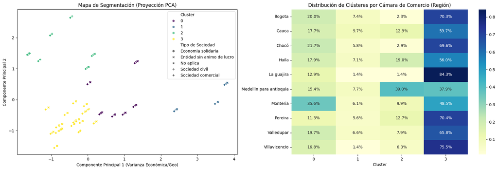

|  | Métrica | Valor | Interpretación |
| --- | --- | --- | --- |
| 0 | Silhouette Score | 0.3648 | Separación (cercano a 1 es mejor) |
| 1 | Calinski-Harabasz Score | 2302.82 | Densidad (más alto es mejor) |
| 2 | Inercia (WCSS) | 1877.87 | Cohesión interna (menor es mejor) |

```python
import matplotlib.pyplot as plt
import seaborn as sns
from sklearn.metrics import silhouette_score, calinski_harabasz_score

# Métricas para juzgar la bondad del clustering
X_processed = pipeline.named_steps['preprocessor'].transform(df_model)
sil_score = silhouette_score(X_processed, df_model['Cluster'])
ch_score = calinski_harabasz_score(X_processed, df_model['Cluster'])

metrics_df = pd.DataFrame({
    'Métrica': ['Silhouette Score', 'Calinski-Harabasz Score', 'Inercia (WCSS)'],
    'Valor': [f"{sil_score:.4f}", f"{ch_score:.2f}", f"{pipeline.named_steps['kmeans'].inertia_:.2f}"],
    'Interpretación': [
        'Separación (cercano a 1 es mejor)',
        'Densidad (más alto es mejor)',
        'Cohesión interna (menor es mejor)'
    ]
})

# Visualizaciones
fig, axes = plt.subplots(1, 2, figsize=(18, 6))

# Distribución Espacial de Clústeres (PCA)
sns.scatterplot(
    data=df_model, x='PCA_1', y='PCA_2',
    hue='Cluster', palette='viridis', style='Tipo de Sociedad',
    alpha=0.7, ax=axes[0]
)
axes[0].set_title('Mapa de Segmentación (Proyección PCA)')
axes[0].set_xlabel('Componente Principal 1 (Varianza Económica/Geo)')
axes[0].set_ylabel('Componente Principal 2')

# Filtramos las top 10 cámaras para que el gráfico sea legible
top_camaras = df_model['Cámara de Comercio'].value_counts().nlargest(10).index
heatmap_data = pd.crosstab(df_model[df_model['Cámara de Comercio'].isin(top_camaras)]['Cámara de Comercio'],
                           df_model['Cluster'], normalize='index')

sns.heatmap(heatmap_data, annot=True, fmt=".1%", cmap="YlGnBu", ax=axes[1])
axes[1].set_title('Distribución de Clústeres por Cámara de Comercio (Región)')
axes[1].set_ylabel('')

plt.tight_layout()
plt.show()

# Mostrar tabla de métricas
display(metrics_df)
```

### Conclusiones del Modelo de Segmentación Regional

El análisis de segmentación revela la existencia de un perfil empresarial hegemónico, identificado en el Cluster 3, que define el comportamiento estándar del emprendimiento colombiano. Este grupo domina transversalmente la geografía nacional, concentrando más del 70% de los registros en ciudades principales como Bogotá o Pereira, e incluso superando el 84% en La Guajira, lo que sugiere una homogeneidad notable en las características de constitución y contexto económico base de la mayoría de las empresas, independientemente de su ubicación.

Desde una perspectiva técnica, las métricas de evaluación validan la consistencia de estos hallazgos dentro de la complejidad inherente a los datos socioeconómicos. Aunque el Silhouette Score de 0.36 refleja una superposición natural entre los grupos debido a la ausencia de fronteras rígidas en este tipo de fenómenos, el elevado índice Calinski-Harabasz de 2302.82 confirma que los clústeres poseen centros densamente definidos, otorgando solidez estadística a la segmentación geográfica identificada.

### Modelo de Clasificación: Predicción de Tipo de Sociedad por Región

Este módulo se enfoca en un problema de clasificación: predecir el `Tipo de Sociedad` más probable para una empresa, dada su `Cámara de Comercio` (proxy de región) y el contexto macroeconómico de su fundación. Para ello, se entrena un modelo de **Random Forest Classifier**, que es robusto ante relaciones no lineales y permite evaluar la importancia de las variables predictoras.

```python
from sklearn.model_selection import train_test_split
from sklearn.ensemble import RandomForestClassifier
from sklearn.metrics import accuracy_score, classification_report, confusion_matrix

target_col = "Tipo de Sociedad"
# Las mismas numericas que usamos para clustering
cat_features = ["Cámara de Comercio", "Categoria de la Matrícula"]
predictive_features = cat_features + num_features

cols_for_classification = predictive_features + [target_col]
df_classification = df[cols_for_classification].dropna().copy()

# Filtramos clases con menos de 2 registros para evitar errores en la estratificación
v_counts = df_classification[target_col].value_counts()
classes_to_keep = v_counts[v_counts >= 2].index
df_classification = df_classification[df_classification[target_col].isin(classes_to_keep)].copy()

# Separar variable objetivo y predictores
X = df_classification[predictive_features]
y = df_classification[target_col]

# Codificación de variables categóricas necesarias para Random Forest
# One-Hot Encoding para Cámara de Comercio y Tipo de Sociedad (si no es target)
# El target 'Tipo de Sociedad' se manejará automáticamente por los clasificadores
ct_clf = ColumnTransformer(
    transformers=[
        ("num", StandardScaler(), num_features),
        (
            "cat",
            OneHotEncoder(handle_unknown="ignore", sparse_output=False),
            cat_features,
        ),
    ],
    remainder="passthrough",
)

X_processed = ct_clf.fit_transform(X)

# Convertir el resultado del ColumnTransformer a DataFrame para que el Random Forest lo maneje bien
# Obtener nombres de columnas después del OneHotEncoding
cat_names = ct_clf.named_transformers_["cat"].get_feature_names_out()
all_feature_names = num_features + list(cat_names)
X_processed_df = pd.DataFrame(X_processed, columns=all_feature_names)

# Dividir datos en entrenamiento y prueba
X_train, X_test, y_train, y_test = train_test_split(
    X_processed_df, y, test_size=0.25, random_state=42, stratify=y
)


# Definición y entrenamiento del modelo random forest
model_rf = RandomForestClassifier(
    n_estimators=200, random_state=42, class_weight="balanced", n_jobs=-1
)
model_rf.fit(X_train, y_train)

y_pred = model_rf.predict(X_test)
```

```
Accuracy General: 0.6382

Reporte de Clasificación:
                             precision    recall  f1-score   support

        Economia solidaria       0.00      0.00      0.00         1
Entidad sin animo de lucro       0.39      0.68      0.49        84
            Sociedad civil       0.07      0.90      0.13        21
        Sociedad comercial       0.95      0.63      0.76       936

                  accuracy                           0.64      1042
                 macro avg       0.35      0.55      0.34      1042
              weighted avg       0.89      0.64      0.72      1042
```

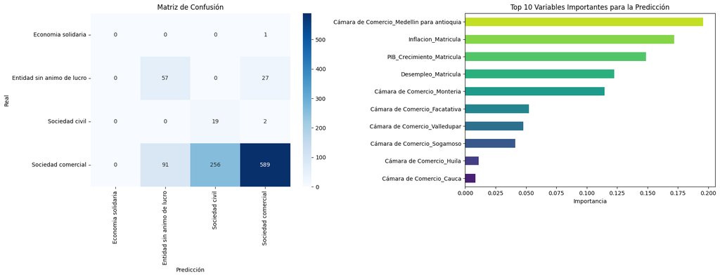

```python
# Métricas
accuracy = accuracy_score(y_test, y_pred)
class_report = classification_report(y_test, y_pred, zero_division=0)
conf_matrix = confusion_matrix(y_test, y_pred)

print(f"Accuracy General: {accuracy:.4f}\n")
print("Reporte de Clasificación:\n", class_report)

# Visualizaciones
fig, axes = plt.subplots(1, 2, figsize=(18, 7))

# Matriz de Confusión
sns.heatmap(
    conf_matrix,
    annot=True,
    fmt="d",
    cmap="Blues",
    ax=axes[0],
    xticklabels=model_rf.classes_,
    yticklabels=model_rf.classes_,
)
axes[0].set_title("Matriz de Confusión")
axes[0].set_xlabel("Predicción")
axes[0].set_ylabel("Real")

# Importancia de las Variables
feature_importances = pd.Series(model_rf.feature_importances_, index=X_train.columns)
top_features = feature_importances.nlargest(10).sort_values(ascending=True)

top_features.plot(
    kind="barh", ax=axes[1], color=sns.color_palette("viridis", len(top_features))
)
axes[1].set_title("Top 10 Variables Importantes para la Predicción")
axes[1].set_xlabel("Importancia")
axes[1].set_ylabel("")

plt.tight_layout()
plt.show()
```

### Conclusiones del Modelo de Clasificación

El desempeño del modelo Random Forest evidencia un desafío crítico derivado del severo desbalanceo en los datos, donde la categoría "Sociedad Comercial" domina masivamente la muestra abarcando cerca del 90% de los registros. Si bien la exactitud general del 63.82% parece aceptable, el ajuste de pesos para equilibrar las clases provocó una distorsión significativa en las predicciones de las categorías minoritarias. Esto es particularmente notable en la "Sociedad Civil", donde el modelo logró identificar el 90% de los casos reales (recall) pero a costa de una precisión extrema del 7%, generando un gran número de falsos positivos al clasificar erróneamente muchas sociedades comerciales como civiles.

Pese a las dificultades de distinción entre clases, el análisis de importancia de variables valida rotundamente la hipótesis de integración de datos. La procedencia geográfica, específicamente de Medellín, resultó ser el predictor más potente, corroborando la singularidad del ecosistema empresarial antioqueño observada en la fase no supervisada. Además, el hecho de que la inflación, el crecimiento del PIB y el desempleo del año de matrícula sean las variables subsiguientes más influyentes confirma que las condiciones macroeconómicas del momento fundacional son determinantes en la elección de la estructura legal de una organización.

Para iteraciones futuras que busquen perfeccionar este enfoque, sería recomendable simplificar la variable objetivo mediante la agrupación de las categorías minoritarias, como entidades sin ánimo de lucro y sociedades civiles, bajo una etiqueta común de "No Comercial". Esta estrategia reduciría el ruido estadístico actual y permitiría al algoritmo construir fronteras de decisión más robustas, mitigando la confusión existente entre las clases con poca representación y la clase dominante.

### Contraste Geográfico de Tipos de Sociedad (Chi-Cuadrado)

Para validar estadísticamente si la ubicación geográfica influye de manera determinante en la elección jurídica de la empresa, se aplica una prueba de independencia **Chi-Cuadrado de Pearson**. Este análisis busca refutar la hipótesis nula de que el `Tipo de Sociedad` y la `Cámara de Comercio` (región) son variables independientes. Dado el desbalanceo detectado previamente en los datos, el script incluye un paso de preprocesamiento para agrupar categorías minoritarias, asegurando que se cumplan las condiciones teóricas de la prueba (frecuencias esperadas mayores a 5 en la mayoría de las celdas), garantizando así la fiabilidad del valor-p resultante.

```python
import scipy.stats as stats

df_chi = df[['Cámara de Comercio', 'Tipo de Sociedad']].dropna().copy()

# Para cumplir la condición de Chi-Cuadrado (frecuencias esperadas > 5),
# agrupamos las cámaras con pocas empresas y los tipos de sociedad minoritarios.

# Agrupar Cámaras: Top 10 + 'Otras'
top_camaras = df_chi['Cámara de Comercio'].value_counts().nlargest(10).index
df_chi['Region_Agrupada'] = df_chi['Cámara de Comercio'].apply(lambda x: x if x in top_camaras else 'Otras Regiones')

# Agrupar Tipos de Sociedad: Mantener los que tengan > 1% de datos, resto a 'Otros'
threshold = len(df_chi) * 0.01
soc_counts = df_chi['Tipo de Sociedad'].value_counts()
valid_socs = soc_counts[soc_counts > threshold].index
df_chi['Sociedad_Agrupada'] = df_chi['Tipo de Sociedad'].apply(lambda x: x if x in valid_socs else 'Otros Tipos')

contingency_table = pd.crosstab(df_chi['Region_Agrupada'], df_chi['Sociedad_Agrupada'])

# Ejecución de la prueba
chi2_stat, p_val, dof, expected = stats.chi2_contingency(contingency_table)

# Cálculo del tamaño del Efecto (V de Cramér)
n = contingency_table.sum().sum()
min_dim = min(contingency_table.shape) - 1
cramers_v = np.sqrt(chi2_stat / (n * min_dim))
```

[figure not shown]

|  | Estadístico Chi2 | P-Valor | Grados de Libertad | V de Cramér | Interpretación |
| --- | --- | --- | --- | --- | --- |
| 0 | 866.08 | 8.2705e-163 | 30 | 0.2568 | Asociación Significativa |

```python
# Visualización
# Heatmap de Residuos Estandarizados (Muestra dónde están las desviaciones significativas)
# Residuo > 2 o < -2 indica desviación significativa
residuals = (contingency_table - expected) / np.sqrt(expected)

plt.figure(figsize=(12, 6))
sns.heatmap(residuals, annot=True, fmt=".1f", cmap="RdBu_r", center=0, linewidths=.5)
plt.title('Mapa de Calor de Residuos Estandarizados\n(Azul = Más frecuencia de la esperada | Rojo = Menos)')
plt.ylabel('Región')
plt.xlabel('Tipo de Sociedad')
plt.show()

results_data = {
    'Estadístico Chi2': [f"{chi2_stat:.2f}"],
    'P-Valor': [f"{p_val:.4e}"], # Notación científica si es muy bajo
    'Grados de Libertad': [dof],
    'V de Cramér': [f"{cramers_v:.4f}"],
    'Interpretación': ['Asociación Significativa' if p_val < 0.05 else 'Independientes']
}

display(pd.DataFrame(results_data))
```

### Conclusiones del Contraste Geográfico

La prueba estadística es concluyente: con un P-Valor virtualmente nulo ($8.27 \times 10^{-163}$) y una V de Cramér de 0.2568, el análisis rechaza categóricamente la hipótesis de independencia, confirmando una asociación moderada pero estructural entre la ubicación geográfica y la forma jurídica adoptada. Esto demuestra que la elección del tipo societario no es un fenómeno aleatorio ni uniforme en el territorio nacional, sino que está fuertemente condicionado por dinámicas locales específicas que alteran la distribución esperada.

El mapa de calor de residuos estandarizados identifica con precisión dónde residen estas discrepancias. Montería emerge como el caso más anómalo del conjunto de datos, exhibiendo una sobrepoblación masiva de "Entidades sin ánimo de lucro" con un residuo extremo de +22.1, lo que sugiere un ecosistema volcado hacia este tipo de organizaciones en detrimento de las comerciales. En contraposición, Medellín para Antioquia muestra un comportamiento inverso y único: presenta un déficit significativo de entidades sin ánimo de lucro (residuo -12.4) compensado por una preferencia inusualmente alta por la "Sociedad Civil" (residuo +8.1), validando matemáticamente la singularidad del tejido empresarial antioqueño observada en los modelos previos.